# OpenStreetMap Data Case Study

## Map Area

San Jose, CA, United States

- (https://mapzen.com/data/metro-extracts/metro/san-jose_california/)

This map is close to my home town and I am interested in knowing all the interesting facts that I can find with my queries.

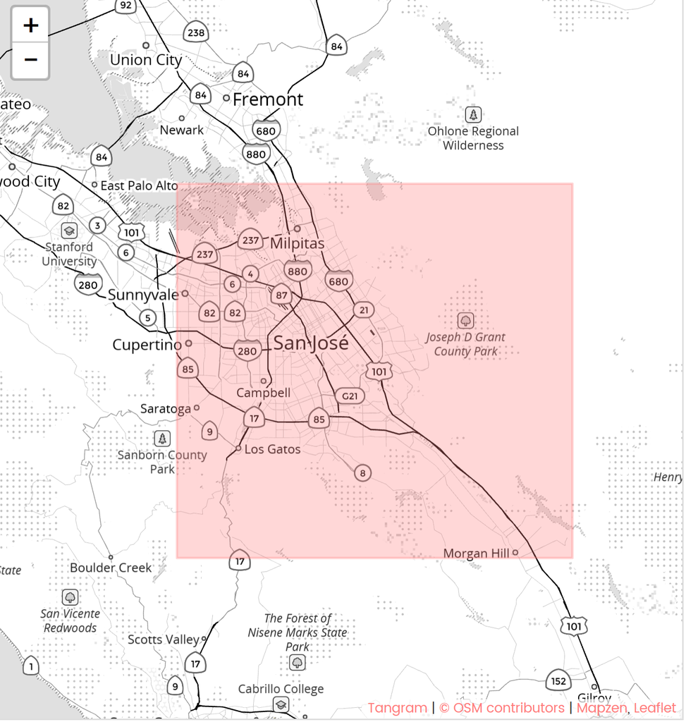

```python
from IPython.display import Image
Image(filename="Capture.png")
```

## Problems Encountered in the Map

After initially downloading and uncompressing the file, I made a small sample file of size 29 MB. I used the data.py python code to run this sample file. I noticed the following problems with the data.

- Abbreviated street names ("N. Mathilda Ave","Wolfe Rd.")
- Inconsistent city names ("SUnnyvale","San José","San Jose")
- Inconsistent postal codes ("CA 95054","95014-2225", "95014")
- Inconsistent phone numbers("1 408 732 4222","1.408.245.5620","+1-800-POLYCOM")

## Abbreviated Street Names

I was able to find most of the inconsistencies in the street names of the sample.osm file using print statements in data.py. To clean the abbreviated street names I used dictionaries for look-ups. The function 'update_addr_name' is implemented in file clean.py. It takes in the street name as input and returns the cleaned street name.

```
Hollenbeck Ave  ---->  Hollenbeck Avenue
Meridian Ave  ---->  Meridian Avenue
Santa Teresa Blvd  ---->  Santa Teresa Boulevard
Monterey Hwy  ---->  Monterey Highway
Minto Dr  ---->  Minto Drive
Cherry Ave  ---->  Cherry Avenue
Los Gatos Blvd  ---->  Los Gatos Boulevard
Walsh Ave  ---->  Walsh Avenue
Meridian Ave  ---->  Meridian Avenue
North McCarthy Blvd  ---->  North McCarthy Boulevard
Foxworthy Ave  ---->  Foxworthy Avenue
Saratoga Los Gatos Rd  ---->  Saratoga Los Gatos Road
Saratoga Los Gatos Rd  ---->  Saratoga Los Gatos Road
```

## Inconsistent City Names

To clean the city names I used dictionary 'mapping_city' for look-ups to match city names with accent on letters, lower case etc. The function 'update_city_name' is implemented in file clean.py.

Here is a sample of the output:

```
San José  ---->  'San Jose'
san jose  ---->  'San Jose'
San José  ---->  'San Jose'
Los Gatos, CA  ---->  'Los Gatos'
San José  ---->  'San Jose'
san Jose  ---->  'San Jose'
sunnyvale  ---->  'Sunnyvale'
sunnyvale  ---->  'Sunnyvale'
San José  ---->  'San Jose'
San José  ---->  'San Jose'
SUnnyvale  ---->  'Sunnyvale'
cupertino  ---->  'Cupertino'
Los Gato  ---->  'Los Gatos'
```

## Inconsistent Postcodes

Some of the postcodes had 9-digits, some had 5-digits and some had the state name in them. I used regex to change the postcodes to 5-digit postcodes to be consistent. The state name was stripped from the postcode and only the postcode was retained. This function 'update_postcode' is implemented in clean.py

Here is a sample of the output:

```
95014-2029  ---->  95014
95014-2405  ---->  95014
95037-3635  ---->  95037
95014-2225  ---->  95014
CA 95054  ----> 95054
95014-2225  ---->  95014
95014-2522  ---->  95014
95014-2522  ---->  95014
CA 95110  ----> 95110
95014-2456  ---->  95014
95014-2456  ---->  95014
95014-2465  ---->  95014
```

## Inconsistent Phone Numbers

The phone numbers were in many different formats and they were made into a standard format: (xxx) xxx-xxxx. I used regex to get all the phone numbers which were in standard form. The rest of the phone numbers were parsed with extra +1,'.' etc removed and made into standard form. This function 'update_phonenum' is implemented in clean.py file.

Here is a sample of the output:

[output not shown]

## Data Overview

The file sizes are:

```
* san-jose_california.osm------------- 295 MB
* sanjose.db-------------------------- 165 MB
* nodes.csv--------------------------- 113 MB
* nodes_tags.csv---------------------- 2.7 MB
* ways.csv----------------------------  10 MB
* ways_tags.csv-----------------------  22 MB
* ways_nodes.csv----------------------  38 MB
```

### Number of nodes

```python
sqlite> SELECT count(*) FROM nodes;
```

1337915

### Number of Ways

```python
sqlite> SELECT count(*) FROM ways;
```

177549

### Number of Unique Users

```python
sqlite> SELECT count(DISTINCT(users.uid)) FROM
   ...> (SELECT uid FROM nodes UNION ALL SELECT uid FROM ways) users;
```

1323

```python
sqlite> SELECT users.user, count(*) as num FROM
   ...> (SELECT user FROM nodes UNION ALL SELECT user FROM ways) users
   ...> GROUP BY users.user
   ...> ORDER BY num DESC
   ...> LIMIT 15;
```

```
nmixter      288079
mk408        151377
Bike Mapper  81330
samely       77912
dannykath    72315
RichRico     71846
karitotp     57291
n76          38018
Minh Nguyen  35071
MustangBuyer 34076
matthieun    32702
calfarome    31620
doug_sfba    30221
beddy        28475
Luis36995    22559
```

### Number of users having 1 post

```python
sqlite> SELECT COUNT(*) FROM
   ...> (SELECT users.user,COUNT(*) as num
   ...> FROM (SELECT user FROM nodes UNION ALL SELECT user FROM ways) users
   ...> GROUP BY users.user
   ...> HAVING num=1);
```

291

### Additional Data Exploration

### Top 10 Cuisines

```python
sqlite> SELECT value,count(*) as cnt FROM nodes_tags
   ...> WHERE key == 'cuisine'
   ...> GROUP BY value
   ...> ORDER BY cnt DESC
   ...> LIMIT 10;
```

```
vietnamese   94
mexican      89
sandwich     88
pizza        79
chinese      76
coffee_shop  55
japanese     43
burger       42
indian       38
american     32
```

### Top 10 Leisure Amenities

```python
sqlite> SELECT value, count(*) as cnt FROM nodes_tags
   ...> WHERE key == 'leisure'
   ...> GROUP BY value
   ...> ORDER BY cnt DESC
   ...> LIMIT 10;
```

```
swimming_pool    147
playground       121
park              63
picnic_table      39
sports_centre     30
pitch             28
fitness_centre    16
slipway            8
dance              6
dog_park           3
```

### Top 10 Religions

```python
sqlite> SELECT value, count(*) as cnt FROM nodes_tags
   ...> WHERE key == 'religion'
   ...> GROUP BY value
   ...> ORDER BY cnt DESC
   ...> LIMIT 10;
```

```
christian       187
buddhist          3
jewish            3
hindu             2
caodaism          1
muslim            1
rosicrucian       1
scientologist     1
shinto            1
sikh              1
```

### City names

```python
sqlite> SELECT DISTINCT value FROM nodes_tags
   ...> where key == 'city' and type == 'addr';
```

```
'Sunnyvale'
'Santa Clara'
'San Jose'
'Morgan Hill'
'Campbell'
'Los Gatos'
'Saratoga'
'Cupertino'
'Mount Hamilton'
'Milpitas'
'Felton'
'Coyote'
'Fremont'
```

### Number of Railway Stations

```python
sqlite> SELECT count(*) FROM nodes_tags
   ...> WHERE key == 'railway' and value == 'station';
```

9

### Number of Theatres

```python
sqlite> SELECT count(*) as cnt FROM nodes_tags
   ...> WHERE key == 'amenity' and value == 'theatre';
```

7

### Addtional Suggestions

It would be great to include local farmer's markets and ice skating information.

To improve the quality of the data, I suggest that there should a standard format that the contributors can enter the data or the system should reject it. We can use scripts to check the format or flag error message when incorrect format is entered by the contributor. This may not be easy to implement initially, since there is a chance that the contributor may stop entering the data. But we could attract the contributor to keep contributing by displaying the rank of the contributors who enter the most data. Also, the contributor may be a user of the map too and would find it much easier to retrieve error-free data.

### Conclusion

The OpenStreetMap of San Jose, California is of reasonably good quality that has an immense depth of information but has some minor typos and different formats of the same data (example: phone numbers entered are of very different formats, city name with and without accent etc.).

### References

- San Jose Map image from https://mapzen.com/data/metro-extracts/metro/san-jose_california/
- Stack overflow for various python questions http://stackoverflow.com/
- Reg expressions regexone.com/references/python
- Stack overflow for SQL questions